# Exp2_pilotdata_hiwis

## Analysis of Test Trials

- Farouts

  In the pilot data from Hiwis, there is still no significant effect but the validity is almost significant with p = .10 Also in the right direction as per the graph

```r
Exp2test_HiwiPilot <- Exp2test_HiwiPilot %>%
  select(Validity,Saliency,Condition,PositionD,PositionT,Distractor1,Distractor2,everything())

#aggregate
Exp2agg_t_hp_fo <- aggregate(data = Exp2test_HiwiPilot,RT_ifo~participant+Validity+Saliency,mean)

aggmean_t_fo <- ddply(Exp2agg_t_hp_fo, .(participant,Validity), summarize, RTmean=mean(RT_ifo), SD = sd(RT_ifo))
salmean_t_fo <- ddply(Exp2agg_t_hp_fo, .(participant,Saliency), summarize, RTmean=mean(RT_ifo), SD = sd(RT_ifo))

kable(aggmean_t_fo, format = "html", caption = "Summary means of valid vs invalid across participant")
```

Summary means of valid vs invalid across participant

| participant | Validity | RTmean | SD |
| --- | --- | --- | --- |
| 2 | invalid | 567.5103 | 8.172226 |
| 2 | valid | 550.3226 | 6.627218 |
| 34 | invalid | 568.9534 | 9.312625 |
| 34 | valid | 558.2821 | 6.091997 |
| 123 | invalid | 624.5370 | 4.803495 |
| 123 | valid | 617.8223 | 10.031909 |
| 1111 | invalid | 583.0000 | 20.692177 |
| 1111 | valid | 583.7105 | 0.260513 |

```r
kable(salmean_t_fo, format = "html", caption = "Summary means of Salient vs non salient across participant")
```

Summary means of Salient vs non salient across participant

| participant | Saliency | RTmean | SD |
| --- | --- | --- | --- |
| 2 | nonsalient | 553.6841 | 11.381011 |
| 2 | salient | 564.1489 | 12.926019 |
| 34 | nonsalient | 569.0641 | 9.156126 |
| 34 | salient | 558.1714 | 5.935498 |
| 123 | nonsalient | 626.4247 | 2.133770 |
| 123 | salient | 615.9345 | 7.362184 |
| 1111 | nonsalient | 576.1316 | 10.978763 |
| 1111 | salient | 590.5789 | 9.973927 |

```r
anova_t_fo <- ezANOVA(data = Exp2agg_t_hp_fo,
        dv = RT_ifo,
        wid = participant,
        within = .(Saliency,Validity),
        detailed = TRUE)

pander(anova_t_fo, style = 'rmarkdown', caption = "ANOVA results: Farouts excluded for test trials")
```

- **ANOVA**:

  Table continues below

  | Effect | DFn | DFd | SSn | SSd | F | p | p<.05 |
  | --- | --- | --- | --- | --- | --- | --- | --- |
  | (Intercept) | 1 | 3 | 5415251 | 9630 | 1687 | 3.176e-05 | * |
  | Saliency | 1 | 3 | 3.114 | 543.8 | 0.01718 | 0.904 |  |
  | Validity | 1 | 3 | 286.7 | 168.2 | 5.113 | 0.1088 |  |
  | Saliency:Validity | 1 | 3 | 75.06 | 164.5 | 1.369 | 0.3265 |  |

  | ges |
  | --- |
  | 0.9981 |
  | 0.0002963 |
  | 0.02656 |
  | 0.007094 |

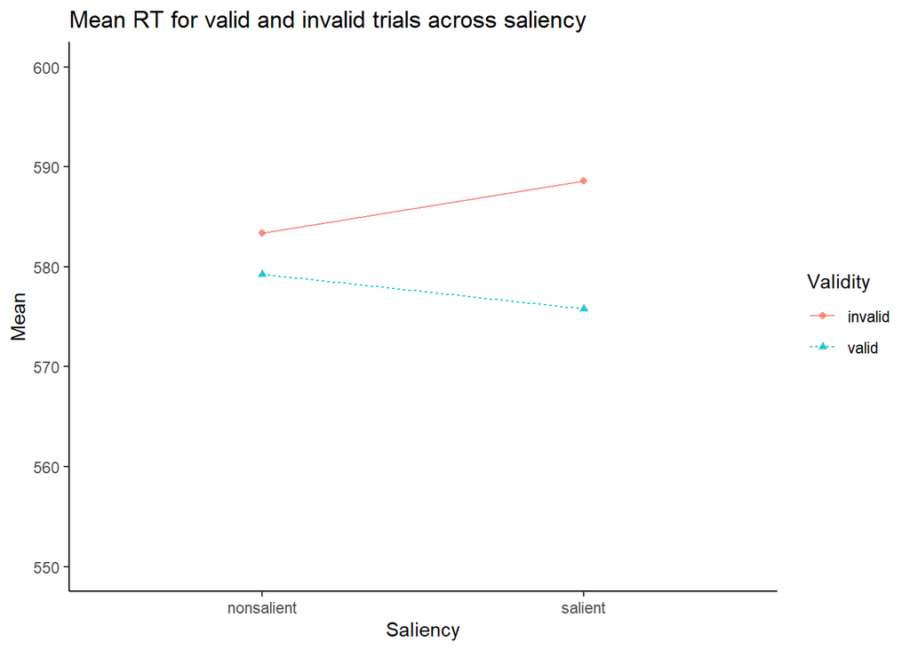

```r
ezPlot(data = Exp2agg_t_hp_fo,
        dv = RT_ifo,
        wid = participant,
        within = .(Saliency,Validity),
        split = Validity, x=Saliency, do_bars = FALSE)+
        theme_classic()+
        ylim(550,600)+
        ggtitle("Mean RT for valid and invalid trials across saliency")
```

- Outliers

Here, the effects are not significant, but atleast the direction seems to be as expected where the mean difference between valid and invalid is larger for salient trials than non salient trials. But not statistically significant.

```r
Exp2agg_t_hp_o <- aggregate(data = Exp2test_HiwiPilot,RT_io~participant+Validity+Saliency,mean)
means_t_o <- aggregate(data=Exp2agg_t_hp_o,RT_io~participant+Validity,mean)
salmeans_t_o <- aggregate(data=Exp2agg_t_hp_o,RT_io~participant+Saliency,mean)


kable(means_t_o, format = "html", caption = "Summary means of valid vs invalid across participant")
```

Summary means of valid vs invalid across participant

| participant | Validity | RT_io |
| --- | --- | --- |
| 2 | invalid | 558.3988 |
| 34 | invalid | 560.4815 |
| 123 | invalid | 617.8475 |
| 1111 | invalid | 560.2113 |
| 2 | valid | 541.5985 |
| 34 | valid | 554.0793 |
| 123 | valid | 614.8645 |
| 1111 | valid | 575.8784 |

```r
kable(salmeans_t_o, format = "html", caption = "Summary means of Salient vs non salient across participant")
```

Summary means of Salient vs non salient across participant

| participant | Saliency | RT_io |
| --- | --- | --- |
| 2 | nonsalient | 544.5725 |
| 34 | nonsalient | 556.3894 |
| 123 | nonsalient | 620.5139 |
| 1111 | nonsalient | 567.6486 |
| 2 | salient | 555.4247 |
| 34 | salient | 558.1714 |
| 123 | salient | 612.1982 |
| 1111 | salient | 568.4410 |

```r
anova_t_o <- ezANOVA(data = Exp2agg_t_hp_o,
            dv = RT_io,
            wid = participant,
            within = .(Saliency,Validity),
            detailed = TRUE)
pander(anova_t_o, style = 'rmarkdown', caption = "ANOVA results: Outliers excluded for test trials")
```

- **ANOVA**:

  Table continues below

  | Effect | DFn | DFd | SSn | SSd | F | p | p<.05 |
  | --- | --- | --- | --- | --- | --- | --- | --- |
  | (Intercept) | 1 | 3 | 5251797 | 10722 | 1469 | 3.905e-05 | * |
  | Saliency | 1 | 3 | 6.53 | 184.2 | 0.1064 | 0.7658 |  |
  | Validity | 1 | 3 | 27.66 | 549.9 | 0.1509 | 0.7236 |  |
  | Saliency:Validity | 1 | 3 | 94.86 | 269.3 | 1.057 | 0.3796 |  |

  | ges |
  | --- |
  | 0.9978 |
  | 0.0005566 |
  | 0.002353 |
  | 0.008025 |

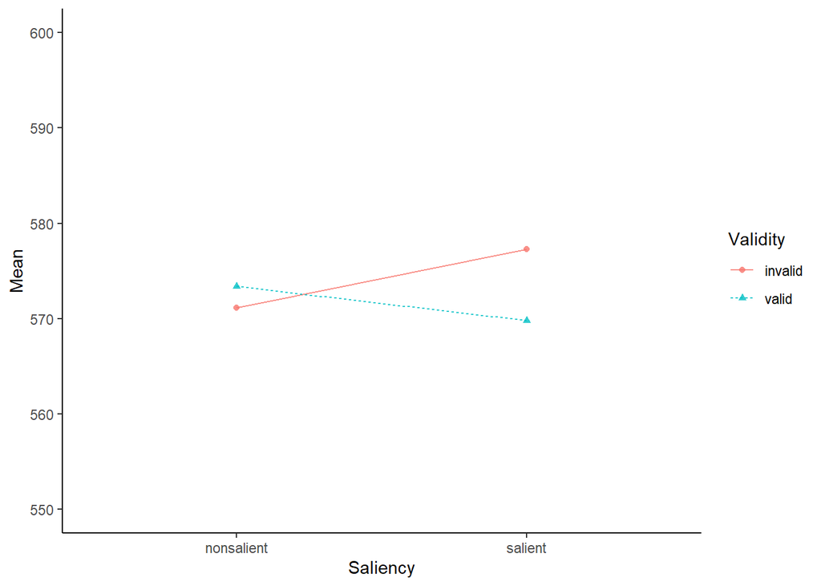

```r
ezPlot(data = Exp2agg_t_hp_o,
        dv = RT_io,
        wid = participant,
        within = .(Saliency,Validity),
        split = Validity, x=Saliency, do_bars = FALSE)+
        ylim(550,600)+
        theme_classic()
```

- Error Rate

  No effects in the error Rates
- **ANOVA**:

  | Effect | DFn | DFd | SSn | SSd | F | p | p<.05 | ges |
  | --- | --- | --- | --- | --- | --- | --- | --- | --- |
  | (Intercept) | 1 | 3 | 306.2 | 40.62 | 22.62 | 0.01765 | * | 0.7368 |
  | Saliency | 1 | 3 | 6.25 | 9.375 | 2 | 0.2522 |  | 0.05405 |
  | Validity | 1 | 3 | 14.06 | 32.81 | 1.286 | 0.3393 |  | 0.1139 |
  | Saliency:Validity | 1 | 3 | 1.562 | 26.56 | 0.1765 | 0.7027 |  | 0.01408 |